# Modelling of Ecosystem-Atmosphere Processes - Photosynthesis and Stomatal Conductance

#### Term Paper in the Module Ecosystem-Atmosphere Processes

by Jonathan Gehret (23301512), Immo Shan (21660614) & Lina Wernicke (26801586) // Date: 31.03.2021

## Introduction

The Earth’s ecosystems and the atmosphere are coupled in a network of physical, biological and chemical processes, forming a complex cycling of energy and substances - the “Earth system”. Terrestrial and aquatic ecosystems are part of it as well as the organisms inhabiting them, including the human population. Due to multiple interconnections between the Earth system’s components, human activities heavily impact the balance between them, causing global changes in climate, water and nutrient cycling, biodiversity and many more (IGBP, 2015).

The magnitude and pace of these human induced changes exceed the natural ranges of change in the Earth system and characterize a new era called the Anthropocene, ringed in by the industrial revolution in the late 18th century. Ever since, the world’s population is rising enormously and with it its consumption of resources and associated waste production. The rapid exploitation and combustion of fossil fuels which have built up over millions of years led to an unprecedented atmospheric concentration of carbon dioxide, methane and other greenhouse gases (IGBP, 2015). Another crucial factor of human impact is land use: As indicated by the Global Human Modification map, 95% of the Earth’s surface has been transformed to different extent by human activities (The Nature Conservancy, n.d.). Land cover change and the effects of fossil fuel combustion result in a feedback cascade between the Earth system’s components, creating challenges of new magnitude for human health. The altered atmosphere composition affects climate as well as plant productivity and thus, requires the adaptation of land uses like agriculture and forestry to sustain future yields.

To adapt to global change, the understanding of the processes between terrestrial ecosystems and the atmosphere is essential. Vegetation closely couples the biosphere with the atmosphere through the continuous exchange of carbon and water. About 30% of the carbon dioxide globally emitted by human activities is removed by the biosphere as well as about 40% of received rain is given back to the atmosphere through plant transpiration (Hawkins et al., 2020). Precipitation, temperature and atmospheric CO2 determine the distribution of vegetation across the Earth and vice versa vegetation types influence atmospheric CO2 concentration and climate through the reflection of radiation and the release of water vapor. Especially forests play an important role and have a major impact on carbon and water cycling, temperature regulation and the albedo of landscapes. Dependent on the type of forest ecosystem and its location, these impacts can mitigate or amplify human-induced climate change (Bonan, 2015, 13 ff.).

The main physiological mechanisms linking the fluxes of CO2, water and energy between atmosphere and vegetation are photosynthesis and stomatal conductance. These closely coupled processes determine the plant’s water-use efficiency by regulating the gas exchange between leaf and air and thereby balancing the loss of water vapor from transpiration against the intake of CO2 for assimilation in response to prevailing environmental conditions (Bonan, 2015, 241 ff.). Influencing factors are, in addition to CO2 concentration and water availability, incoming radiation, temperature as well as soil parameters - all these need to be considered in analyzing land-atmosphere relations.

A comprehension of the complex correlations between atmosphere and terrestrial ecosystems is difficult to establish through mere observations. To properly connect all involved components and display their interdependencies with each other, computer models are indispensable. Such models merge simulation approaches from meteorological, hydrological and ecological points of view, forming useful research tools to investigate the impacts of global change (Bonan, 2019, 1 ff.). To display how ecosystems will react to ongoing change, an extrapolation of known data is inappropriate because it cannot predict future responses under changed environmental conditions. More confidence in predictions is given in modelling approaches derived from ecological theory with explicit assumptions about causal mechanisms within a system. Their grounding on mathematical equations makes these process-based models easier to interpret compared to other modelling approaches - as long as included ecological processes are relevant and refer to appropriate spatial and temporal scales. But even then, confidence in predictions is limited due to uncertain scopes of global change (Cuddington et al., 2013). To evaluate the accuracy of model predictions, the simulation of ecosystem responses to past conditions can be harnessed: If the modelled simulations fit measured data - especially of extreme weather conditions like droughts or heat waves - the model is likely to be able to predict future scenarios as well (Hawkins et al., 2020).

This bottom-up modelling approach was applied within the module “Ecosystem-Atmosphere Processes” to simulate the fluxes of substances and energy between a forest ecosystem and the atmosphere. The model development followed the structure of Bonan (2019), split into five sub-models created by student groups for the sections of soil hydrology and temperature, soil carbon cycling, radiative transfer, leaf temperature and photosynthesis and stomatal conductance. The data to be fitted with the simulation origins from continuous measurements of a research site in the Hainich National Park in Thuringia, Germany. The measuring tower is located in an unmanaged old beech forest which is part of the largest coherent deciduous woodland in Germany. The beech (Fagus sylvatica) is a common species in natural forests of Central Europe and is the potential natural vegetation of wide parts of Germany (Nationalpark Hainich, n.d.). How the Hainich beech forest responds to certain environmental conditions might help to predict how the distribution area of Fagus sylvatica could shift in future or how much more resilient natural forests are compared to managed forest stands regarding climate change.

This term paper describes the development of the sub-model for the processes of photosynthesis and stomatal conductance for the Hainich site, including underlying theory and an evaluation and discussion of the results.

## Theory

The leaf photosynthesis model can essentially be divided into two interacting components which are modeled individually. These two components are photosynthesis in the form of net assimilation and stomatal conductance as chemical flux in and out of the leaf. The following theoretical explainations attempt to outline the calculations and relationships that were applied in the photosynthesis model. All theory, equations and figures are obtained from Bonan (2019) **Chapter 11** and **12**.

### Photosynthesis

Photosynthesis is calculated using the Farquhar-von Caemmerer-Bernacchi model (FvCB model) that mathematically describes the C3 photosynthesis pathway. The foundation for the model is formulated as

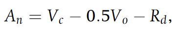

**1.1: An = net assimilation(μmol CO2 m–2 s–1), Vc = carboxylation limited hotosynthesis, Vo = oxygenation limited loss of carbon, Rd = mitochondrial respiration**

To calculate carboxylation and oxygenation, the Michaelis Menten response functions are used which calculate carboxylation and oxygenation from the maximum rates (**Vcmax/Vomax**), intercellular concentrations (**ci, oi**) and the michaelis menten constants (**Kc and Ko**).

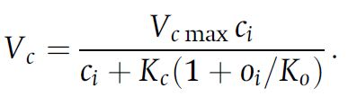

**1.2: Michaelis Menten Formula for carboxylation**

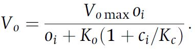

**1.3: Michaelis Menten Formula for oxygenation**

Since oxygenation leads to loss of carbon, an intercellular carbon concentration exists at which no CO2 is taken up. This concentration is called the CO2 compensation point and is calculated by

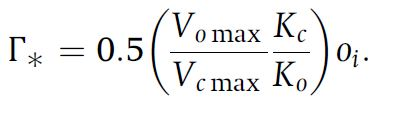

**1.4: Calculation of the CO2 compensation point**

Furthermore assimilation is not only limited by the maximum rate of carboxylation but also by the rate at which Ribulose 1,5-bisphosphate (**RuBP**) is regenerating. This depends on light absorption and the electron transport in the photosystems (**Jmax**) which is typically termed product limited assimilation. These assimilation types can account for **Vo** if the CO2 compensation point is regarded and are calculated by

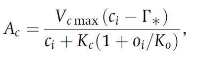

**1.5: Calculation of Rubisco limited photosynthesis rate**

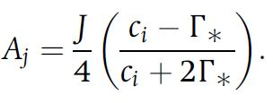

**1.6: Calculation of product limited photosynthesis rate**

The net assimilation according to the FvCB model therefore can be formulated as

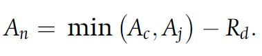

**1.7**

which is the minimum assimilation out of both carboxylation-limited- (Rubisco limited) and product-limited assimilation.  
To account for different enzyme kinetics at varying temperatures, temperature acclimation has to be incorporated using the Arrhenius function which is normalized to 25°C

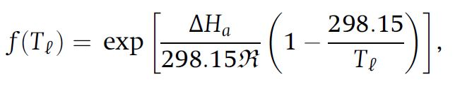

**1.8: Arrhenius function** as a function of leaf temperature (Tl in K) with R = universal gas constant, DeltaHa = activation energy

This function can be used in its peaked form to adapt the various parameters of the model (such as Vcmax, Jmax, Kc, Ko, etc.) from 25°C standard values to the appropriate growth temperature.

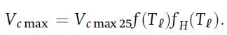

**1.9: Peaked Arrhenius function for Vcmax** with f(Tl)H = thermal berakdown of biochemical processes

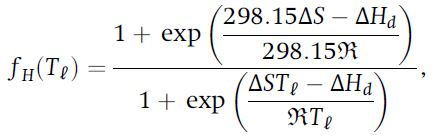

**1.10: Thermal Breakdown of biochemical processes** with DeltaS = entropy term for parameter in question; DeltaHd = deactivation energy

The entropy term for the thermal breakdown of biochemical processes can be calculated from temperature by

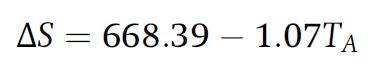

**1.11: Calculation of entropy term for Vcmax**

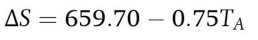

**1.12: Calculation of entropy term for Jmax**

### Stomatal Conductance

To calculate intercellular CO2 concentration for photosynthesis it is necessary to know the conductance of the stomata. This can be understood from

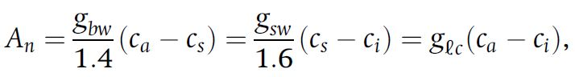

**2.1: Calculation of net assimilation with conductances; ca, cs, ci = ambient, surface and intercellular CO2 concentration (μmol mol–1); gbw, glc, gsw = boundary layer, leaf and stomata conductances for H2O (mol H2O m–2 s–1)**

In order for CO2 to diffuse into the cell, a concentration gradient from outside to inside the cell is required. This is a dependency which is formulated in the photosynthetic diffusion equation

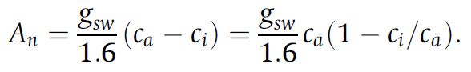

**2.2**

which can be rearragend to

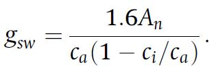

**2.3**

Since this is a linear relationship between net assimilation and stomatal conductance, a slope can be calculated and a ratio of intercellular to ambient CO2 concentration is used to calculate stomatal conductance if **ci** is known. The relationship between intercellular CO2 concentration, net assimilation and stomatal conductance can be rewritten to focus on the leaf surface which is done for the Ball Berry model of stomata conductance.

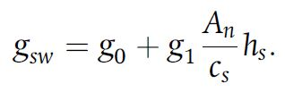

**2.4: Ball berry model of stomata conductance or stomata constraint function with hs = fractional humidity at the leaf surface (dimensionless), g1 = slope of the relationship, g0 = minimum conductance (mol H2O m–2 s–1)**

This model focuses on leaf surface humidity and boundary layer CO2 concentration while aiming to satisfy the interaction between stomatal conductance and net assimilation. This interaction can be mathematically described by solving a set of net assimilation two equations for intercellular CO2 concentration. Net assimilation of CO2 is governed by the biochemical demand for CO2, the diffusive supply and a stomatal constraint function. The constraint function can be combined with the supply function

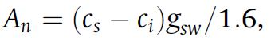

**2.5: Diffusive supply function**

to yield the supply-constraint function

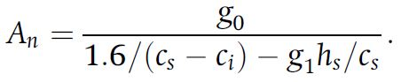

**2.6: Supply-constraint function**

The biochemical demand is calculated as follows, depending on the photosynthesis limiting factor.

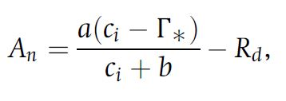

**2.7: Biochemical demand function with a and b depending on wether photosynthesis is limited by carboxylation (a = Vcmax & b = Kc(1+oi/Ko) or electron transport (a = J/4 & b = 2xCO2 compensation point)**

To calculate **ci** dependent on a given leaf temperature, an iterative approach can be taken which uses an initial **ci** value and adapts this value until it satisfies the biochemical demand function as well as the diffusive supply-constraint function. This approach is graphically described in the following figure and is also applied in the model. The calculation is repeated until the old and new **ci** values converge. (Figure 1)

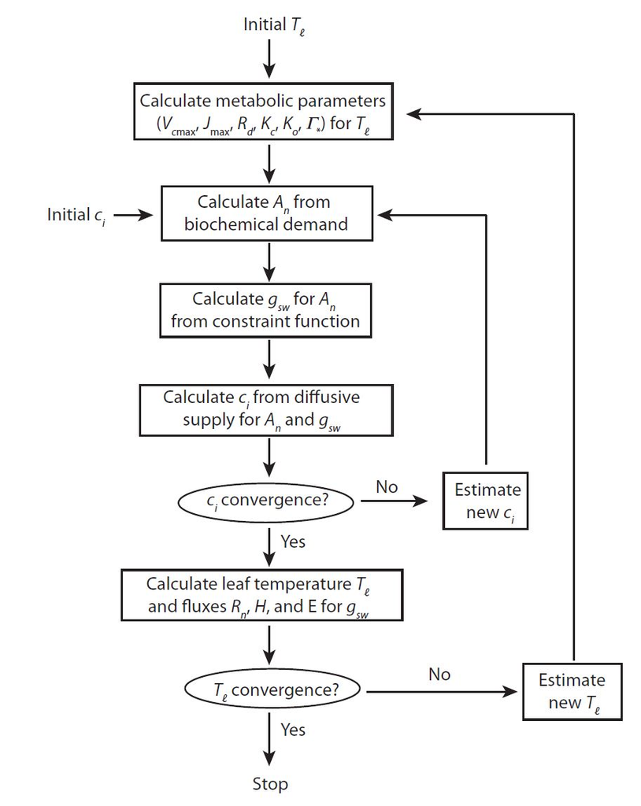

**Figure 1: Iterative approach for calculating ci**

## Model development

## Model results and evaluation

### Calibration

### Sensitivity analysis

The sensitivity analysis has been conducted with assumed central values of Vcmax = 60 and g1 = 9. These approximate values have been taken from Kattge et al. (2009). (Figure 2.1) The model ran for a duration of 1 month (July 2018) and the values were decreased and increased by 25% and 50% respectively. The oscillations represent day and night cycles. To superficially understand the sensitivity of the model, the output was visually compared in each direction.

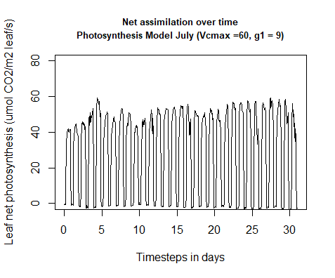

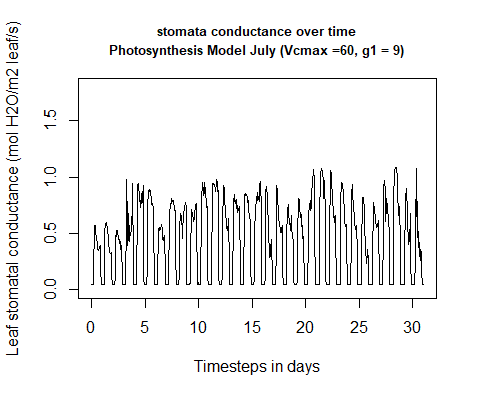

**Figure 2.1: net assimilation and stomatal conductance under central values of Vcmax and g1** #### Vcmax modification

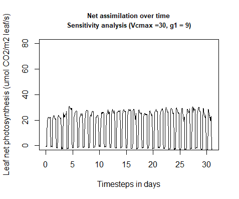

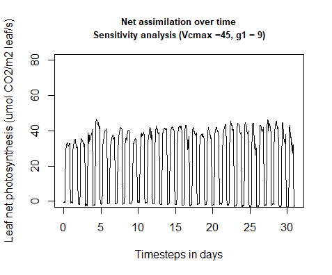

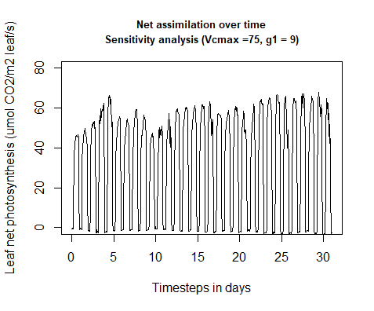

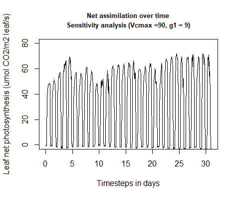

**Figure 2.2: Net assimilation response to sensitivity analysis (Vcmax modification)**